We we will look at univariate statistics for two variables: Received ODA and Democratic Index

First, we will look at mean and median ODA over time

```r
library(dplyr)
library(tidyverse)
library(readxl)
AidData <- read_excel("AidData.xls")
DI <- read_excel("DI.xlsx")
```

```r
options(scipen = 999)
AidData %>% gather(year, aid_received,"1960":"2018", na.rm=TRUE) -> sorted_data
```

```r
sorted_data %>%
  filter(year == 2016) -> aid2016
```

```r
summarymod <-
  sorted_data %>%
    group_by(year) %>%
    summarise(mean_aid = mean(aid_received),
              median_aid = median(aid_received),
              num = n())
```

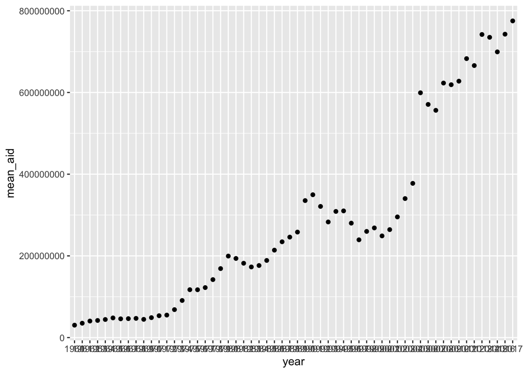

```r
summarymod %>%
  ggplot() +
    aes(x = year , y = mean_aid) +
      geom_point()
```

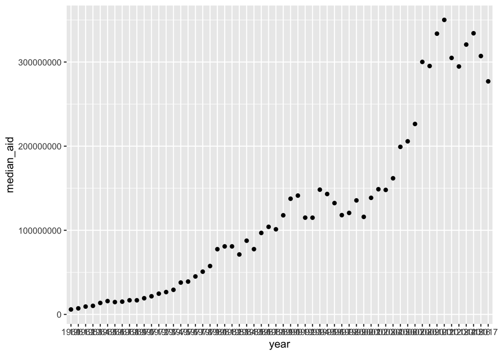

```r
summarymod %>%
  ggplot() +
    aes(x = year , y = median_aid) +
      geom_point()
```

```r
  ggsave("figure.png")
```

Aid is steadily increasing over time. However, the last dozen data points seem to be at a similar level. Now we turn our attention to the year 2016.

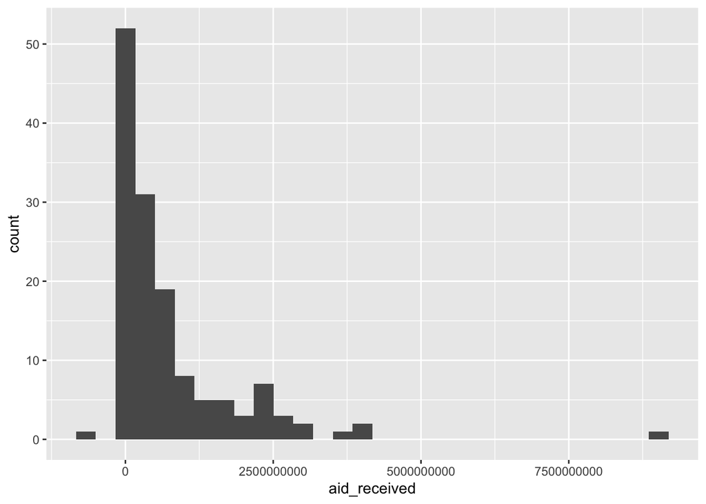

```r
aid2016 %>%
  ggplot() +
    geom_histogram() +
      aes(x=`aid_received`, binwidth=0.01)
```

```r
aid2016 %>%
  summarise(mean2016 = mean(aid_received), median2016 = median(aid_received))
```

```
## # A tibble: 1 x 2
##     mean2016 median2016
##        <dbl>      <dbl>
## 1 742709214.  307140000
```

Now we look at Democratic Index for the year 2016.

```r
DI %>%
  select(Country, Year, `Democracy index (EIU)`) -> d
colnames(d)[1] <- "Country Name"
colnames(d)[2] <- "year"
dcon <-
  d %>%
  filter(year >2010)
dcon %>%
  filter(year == 2016) -> d16
```

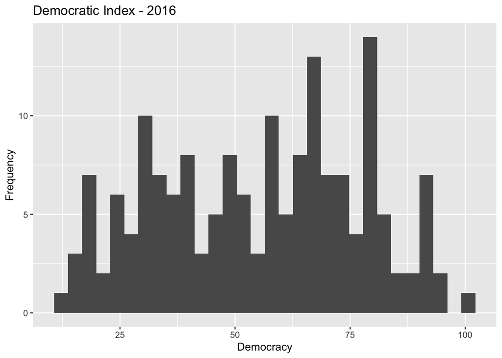

```r
d16 %>%
  ggplot() +
    geom_histogram() +
      aes(x=`Democracy index (EIU)`) +
        labs(title = "Democratic Index - 2016", y = "Frequency", x = "Democracy")
```

```r
d16 %>%
  summarise(mean2016 = mean(`Democracy index (EIU)`), median2016 = median(`Democracy index (EIU)`))
```

```
## # A tibble: 1 x 2
##   mean2016 median2016
##      <dbl>      <dbl>
## 1     55.2       57.2
```

Now we merge the Aid and Democracy data to do a bivariate analysis.

```r
options(scipen = 999)
AidData %>% gather(year, aid_received,"1960":"2018", na.rm=TRUE) -> sorted_data
sorted_data %>%
  filter(year == 2016) -> aid2016
```

```r
DI %>%
  select(Country, Year, `Democracy index (EIU)`) -> d
colnames(d)[1] <- "Country Name"
colnames(d)[2] <- "year"
dcon <-
  d %>%
  filter(year >2010)
dcon %>%
  filter(year == 2016) -> d16
```

```r
dcon %>%
  filter(year == 2016) -> d16
a16 <- merge(d16,aid2016, by=c("Country Name","year"))
colnames(a16)[3] <- "dem"
colnames(a16)[4] <- "aid"
```

We try to establish the relationship betweeen Aid Received and Level of Demoracy by running a correlation test.

```r
cor.test(x = a16$dem, y = a16$aid)
```

```
##
##  Pearson's product-moment correlation
##
## data:  a16$dem and a16$aid
## t = -1.4641, df = 95, p-value = 0.1465
## alternative hypothesis: true correlation is not equal to 0
## 95 percent confidence interval:
##  -0.33797635  0.05245536
## sample estimates:
##       cor
## -0.148544
```

P value greater than 0.05 suggest that the correlation is not statistically signficant.

We try to a fit a linear model to the data.

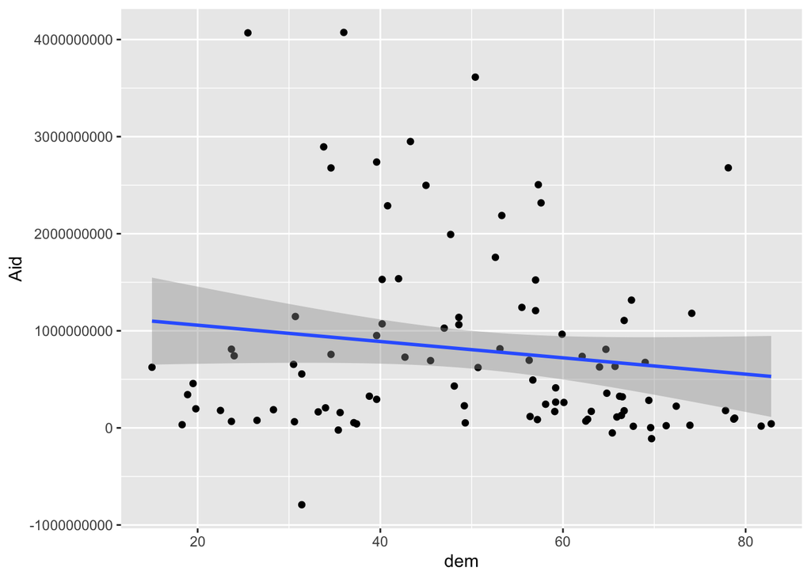

```r
a16 %>%
  ggplot() +
  aes(x = dem, y = aid) +
    geom_point() +
    labs(y="Aid") +
  geom_smooth(method = lm, formula = y ~ x)
```

```r
model1 <- lm(formula = aid ~ dem, data = a16)
summary(model1)
```

```
##
## Call:
## lm(formula = aid ~ dem, data = a16)
##
## Residuals:
##         Min          1Q      Median          3Q         Max
## -1753564092  -604792457  -346851437   245865813  3150144604
##
## Coefficients:
##               Estimate Std. Error t value Pr(>|t|)
## (Intercept) 1225921709  305567656   4.012  0.00012 ***
## dem           -8404064    5740203  -1.464  0.14648
## ---
## Signif. codes:  0 '***' 0.001 '**' 0.01 '*' 0.05 '.' 0.1 ' ' 1
##
## Residual standard error: 965900000 on 95 degrees of freedom
## Multiple R-squared:  0.02207,    Adjusted R-squared:  0.01177
## F-statistic: 2.144 on 1 and 95 DF,  p-value: 0.1465
```